# Lecture 16: Areal Data Overview

# Class Intro

## Intro Questions

- We recently wrapped up the section on geostatistical or point-reference data. Assume you have two minutes with a recruiter, explain what you have learned thus far.
- For Today:
  - Areal Data

# Areal Data Overview

## Areal Data

Defining features: random observation measured at well defined subsets, such as a city or state.

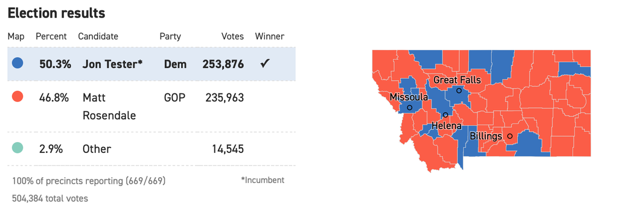

source: https://www.politico.com/election-results/2018/montana/

## Areal Data

**Recall:** How can spatial information be incorporated with this data structure?

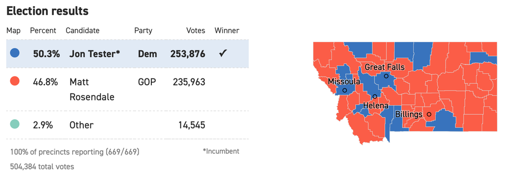

source: https://www.politico.com/election-results/2018/montana/

## Areal Data Model Overview

- Data, typically averages or totals, are captured for geographic units or blocks
- Spatial correlation is incorporated with a *neighbor* structure.
- Autoregressive models on the neighbor structure capture spatial similarities.
- Model based approaches will incorporate covariates and introduce spatial structure with random effects.

## Areal Data Inferential Questions

1. Is there a spatial pattern?
2. In presenting a map of expected responses, should the raw values or a smoothed response be presented?
3. What values would be expected for new set of areal units?

# Exploratory Methods for Areal Data

## Data Viz Options

Creating choropleth maps:

- [Poverty in Nepal with ggplot](https://medium.com/@anjesh/step-by-step-choropleth-map-in-r-a-case-of-mapping-nepal-7f62a84078d9)
- [Plotly](https://plot.ly/r/choropleth-maps/#choropleth-maps-in-r)
- [Crime in Philly](https://cengel.github.io/rspatial/4_Mapping.nb.html)
- [State and County Population](http://www.bargava.com/Intro-to-Choropleth-using-R/)

## Leaflet Tutorial

Follow the [Leaflet tutorial](https://rstudio.github.io/leaflet/choropleths.html) for creating choropleths.

- what is the object `states`?
- based on my drives through South Dakota, I’m convinced there is a data entry error with the density for South Dakota. Fix this.

## Choropleth Tutorial # 2

- What are the objects `urbnmapr::states` and `urbnmapr::counties`?
- What is `urbnmapr::countydata`?
- Why do you think there only 6 colors for the state?

## Choropleth Tutorial # 3

- Now download the election results and create two maps by county.
1. Total number of votes for Tester
2. Proportion of votes for Tester

# Exploratory Approaches for Areal Data

## Proximity Matrix

- Similar to the distance matrix with point-reference data, a proximity matrix $W$ is used to model areal data.
- Given measurements $Y_i, \dots, Y_n$ associated with areal units $1, \dots, n$, the elements of $W$, $w_{ij}$ connect units $i$ and $j$
- Common values for $w_{ij}$ are
  $$w_{ij} =\begin{cases} 1 & \text{if i and j are adjacent} \\
  0& \mbox{otherwise (or if i=j) }
  \end{cases}$$

## Grid Example

- Create an adjacency matrix with diagonal neigbors
- Create an adjacency matrix without diagonal neigbors

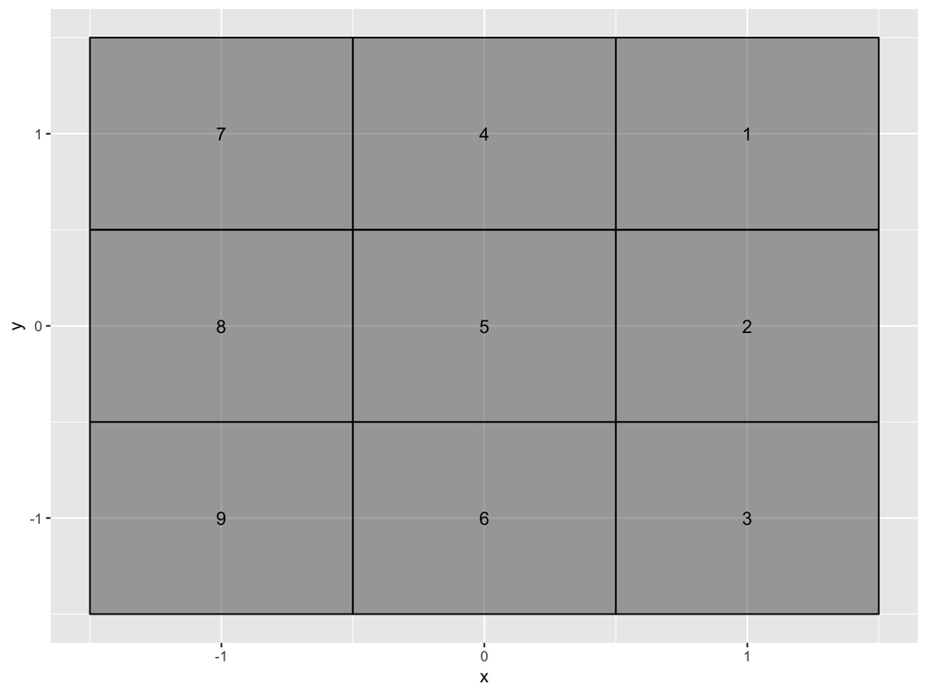

## Spatial Association

There are two common statistics used for assessing spatial association: Moran’s I and Geary’s C.

- Moran’s I
  $$I =\frac{n \sum_i \sum_j w_{ij} (Y_i - \bar{Y})(Y_j -\bar{Y})}{(\sum_{i\neq j \;w_{ij}})\sum_i(Y_i - \bar{Y})^2}$$
- Geary’s C
  $$C=\frac{(n-1)\sum_i \sum_j w_{ij}(Y_i-Y_j)^2}{2(\sum_{i \neq j \; w_{ij}})\sum_i (Y_i - \bar{Y})^2}$$